# Classifying Violent Speech

Blake Miller

27 March 2023

## Classifying Violent Speech

The following data come from a research project of mine that involves identifying violent speech in the comments of news articles. As you can imagine, some of the comments in this dataset are disturbing. As I have stressed when we’ve discussed other difficult subjects in class, please do take care when working with these data. Many of the comments here are racist, sexist, islamophobic, homophobic, etc.

In this dataset, we aim to classify whether a comment is violent. By violent, we mean the following:

- Does the text mention or imply support for or a desire to use physical violence against individuals and/or groups or the confiscation/destruction of property?
- Is the violence represented in the text credible? For example, “I will kill you” (credible) vs. “I could just about kill you if you show up late again” (not credible)

Let’s look at the dataset.

```r
download.file('https://github.com/lse-my474/pset_data/raw/main/hate_speech.csv', 'hate_speech.csv')

vio_data <- read.csv('hate_speech.csv')
nrow(vio_data)
```

```
## [1] 27207
```

```r
length(unique(vio_data$article_id))
```

```
## [1] 16
```

```r
names(vio_data)
```

```
## [1] "id"          "article_id"  "raw_message" "ATT_CODE"    "GRO_CODE"
## [6] "VIO_CODE"
```

The data consist of 27207 comments from 16 news articles. The data have the following columns:

- `id`: the id of the comment
- `article_id`: the id of the article
- `raw_message`: the raw text of the comment
- `ATT_CODE`: code for personal attack (yes=1, no=0)
- `GRO_CODE`: code for mention of a group (yes=1, no=0)
- `VIO_CODE`: code for violence (yes=1, no=0)

1571 of these comments are labeled and 25636 are unlabeled. These labeled comments have been randomly sampled from the population of comments on these articles.

```r
labeled <- vio_data[!is.na(vio_data$VIO_CODE),]
nrow(labeled)
```

```
## [1] 1571
```

```r
unlabeled <- vio_data[is.na(vio_data$VIO_CODE),]
nrow(unlabeled)
```

```
## [1] 25636
```

Let’s train a lasso classifier on these labeled comments to predict if a comment is violent (outcome `VIO_CODE`. After, we’ll see how to query new documents to label using active learning and uncertainty sampling. This should give you the tools to use active learning to label your data, though unfortunately, this process takes a good amount of time and we can’t cover the whole process in class.

```r
library(quanteda)
# Load in data as a quanteda corpus
corpus <- corpus(vio_data, text_field = 'raw_message')

# Create a matrix of word counts
toks <- tokens(corpus)
toks <- tokens_remove(toks, stopwords('en')) # remove common terms (stopwords)
dfm <- dfm(toks)
dfm <- dfm_trim(dfm, min_docfreq = 2) # removing rare terms
dfm
```

```
## Document-feature matrix of: 27,207 documents, 13,679 features (99.90% sparse) and 5 docvars.
##        features
## docs    1 % joe got package  . took behind another ploy
##   text1 1 1   1   1       1 11    1      1       0    0
##   text2 0 0   0   0       0  7    0      0       1    1
##   text3 0 0   0   0       0  0    0      0       0    0
##   text4 0 0   0   0       0  1    0      0       0    0
##   text5 0 0   0   0       0  5    0      0       0    0
##   text6 0 0   0   0       0  3    0      0       0    0
## [ reached max_ndoc ... 27,201 more documents, reached max_nfeat ... 13,669 more features ]
```

```r
# Separate labeled documents from unlabeled documents
unlabeled <- dfm_subset(dfm, is.na(vio_data$VIO_CODE))
labeled <- dfm_subset(dfm, !is.na(vio_data$VIO_CODE))

# Split into train and test set to estimate generalization error
tr <- sample(nrow(labeled), floor(nrow(labeled) * 0.8))
label <- factor(labeled$VIO_CODE, levels=c(1,0))
```

Our first step is to train the classifier, selecting lambda using cross-validation. We’ll start with a lasso regression:

```r
library(glmnet)
require(doMC)
```

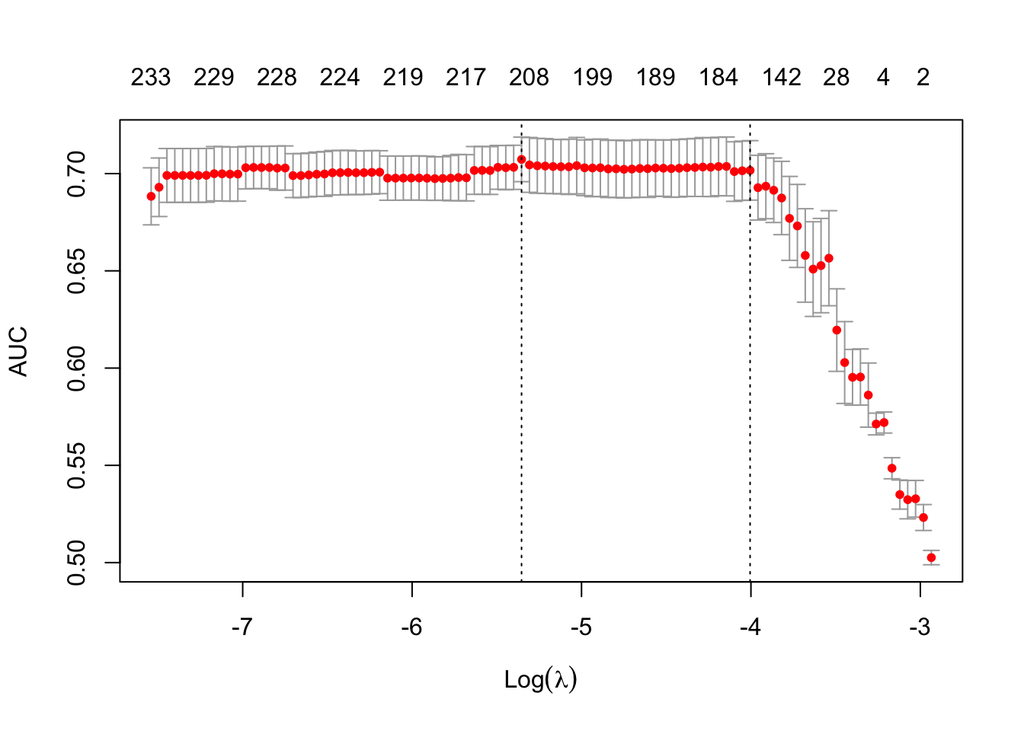

```r
registerDoMC(cores=3) #functions for parallel execution of R code on machines with multiple cores or processors
lasso <- cv.glmnet(labeled[tr,], label[tr],
    family="binomial", alpha=1, nfolds=5, parallel=TRUE,
    type.measure="auc")

plot(lasso)
```

We can now compute the performance metrics on the test set.

```r
## function to compute accuracy
accuracy <- function(ypred, y){
    tab <- table(ypred, y)
    return(sum(diag(tab))/sum(tab))
}
# function to compute precision
precision <- function(ypred, y){
    tab <- table(ypred, y)
    return((tab[2,2])/(tab[2,1]+tab[2,2]))
}
# function to compute recall
recall <- function(ypred, y){
    tab <- table(ypred, y)
    return(tab[2,2]/(tab[1,2]+tab[2,2]))
}
# computing predicted values
preds <- predict(lasso, labeled[-tr,], type="class")
# confusion matrix
table(preds, label[-tr])
```

```
##
## preds   1   0
##     0  30 276
##     1   5   4
```

```r
# performance metrics
accuracy(preds, label[-tr])
```

```
## [1] 0.1079365
```

```r
# for specific rows
precision(preds==1, label[-tr]==1)
```

```
## [1] 0.5555556
```

```r
recall(preds==1, label[-tr]==1)
```

```
## [1] 0.1428571
```

```r
precision(preds==0, label[-tr]==0)
```

```
## [1] 0.9019608
```

```r
recall(preds==0, label[-tr]==0)
```

```
## [1] 0.9857143
```

Not so great… violence in comments is uncommon, so this is an **imbalanced classification problem**. This means if we are randomly sampling comments, there is only a small chance we will come across violent comments. Let’s be precise; we have an unbiased estimate of the proportion of violent comments in our dataset since we have been randomly sampling comments to label up until now.

```r
table(labeled$VIO_CODE)
```

```
##
##    0    1
## 1428  143
```

```r
143/1428
```

```
## [1] 0.1001401
```

It appears violent comments appear in one out of ten comments, a high class imbalance. We could likely benefit from active learning as we label new observations. Let’s find the comments that the classifier is most uncertain of. We do so by finding the unlabeled observations closest to the decision boundary. We do this using `predict()` on the unlabeled observations and obtaining the distance from a predicted probability of .5 (i.e., decision boundary). Since we don’t really care about which side of .5 our unlabeled observations fall—we just care about how close observations are to it—we take the absolute value of this distance using `abs()`.

```r
pred <- predict(lasso, unlabeled, type="response") # Predicted probabilities
sorted <- sort(abs(pred - .5), decreasing=FALSE, index.return=TRUE)
pred[head(sorted$ix)] # Predicted probabilities closest to .5
```

```
## [1] 0.4989417 0.5048818 0.4944436 0.4944436 0.5078974 0.5078974
```

```r
head(sorted$x) # Distance from .5
```

```
## [1] 0.001058282 0.004881771 0.005556370 0.005556370 0.007897411 0.007897411
```

```r
to_label <- unlabeled[sorted$ix[1:10],]
indexes <- as.numeric(rownames(to_label))
as.character(corpus[rownames(to_label),])
```

```
##                                                                                                                                                                                                                                                                                                          …
##                                  "Obama banned Christians from the Middle East to come to the USA. Why the press didn't cry discrimination then? Besides, can a liberal explain why muslims kill muslims? Because there is a radical sect of muslims called ISIS that want to impose sharia law across th…
##                                                                                                                                                                                                                                                                                                          …
## "Send out dump trucks with snow plow blades mounted on front and just drive full speed through these animals, toss the carcasses in the back without worrying if any are still twitching, dump them all in a landfill and then cover the lot up with twenty feet of raw sewage so that their stench doesn…
##                                                                                                                                                                                                                                                                                                          …
##                                                                                                                                                                                                       "The libs are really gonna have a hissy fit when they learn that the immigration ban is not only pe…
##                                                                                                                                                                                                                                                                                                          …
##                                                                 "No matter your own ancestry, whether by slavery, illegal or legal immigration, as an American you are not under ANY obligation to accept ANY immigrants.\n\nI am soooo over the white guilt-trip bullshit, and I reject any and all effo…
##                                                                                                                                                                                                                                                                                                          …
##                                                                                                                                                                                            "Quick! send the police to arrest anyone expressing islamophobia. \n\nAnd for God's sake, will someone please …
##                                                                                                                                                                                                                                                                                                          …
##                                                                                                                                                                                                                                                                                     "the protestors are i…
##                                                                                                                                                                                                                                                                                                          …
```

[output cut: 7 more lines]

5/10 of these comments indeed are violent. I’ve commented them out since they are offensive, but if you would like to try this on your own, make sure you are aware that some of these comments are extremely unpleasant. We ended up retrieving way more than the expected 1/10 violent comments. By labeling documents closest to the decision boundary, we can achieve better class balance in our training data, improving the performance of our model more quickly.